# Supervised Learning Project

# Steps and Tasks :

# 1.Data Understanding :

```python
import pandas as pd
import numpy as np
import warnings
warnings.filterwarnings('ignore')
```

## Question 1.a

1.A Read all the 3 CSV files as DataFrame and store them into 3 separate variables.

```python
x=pd.read_csv("C:\\Users\\HARITHA\\Pictures\\Great Learning project\\Supervised Learning\\Normal.csv")
y=pd.read_csv("C:\\Users\\HARITHA\\Pictures\\Great Learning project\\Supervised Learning\\Type_H.csv")
z=pd.read_csv("C:\\Users\\HARITHA\\Pictures\\Great Learning project\\Supervised Learning\\Type_S.csv")
```

```python
df=pd.DataFrame(x)
af=pd.DataFrame(y)
cf=pd.DataFrame(z)
```

```python
df
```

|  | P_incidence | P_tilt | L_angle | S_slope | P_radius | S_Degree | Class |
| --- | --- | --- | --- | --- | --- | --- | --- |
| 0 | 38.505273 | 16.964297 | 35.112814 | 21.540976 | 127.632875 | 7.986683 | Normal |
| 1 | 54.920858 | 18.968430 | 51.601455 | 35.952428 | 125.846646 | 2.001642 | Normal |
| 2 | 44.362490 | 8.945435 | 46.902096 | 35.417055 | 129.220682 | 4.994195 | Normal |
| 3 | 48.318931 | 17.452121 | 48.000000 | 30.866809 | 128.980308 | -0.910941 | Normal |
| 4 | 45.701789 | 10.659859 | 42.577846 | 35.041929 | 130.178314 | -3.388910 | Normal |
| ... | ... | ... | ... | ... | ... | ... | ... |
| 95 | 47.903565 | 13.616688 | 36.000000 | 34.286877 | 117.449062 | -4.245395 | Normal |
| 96 | 53.936748 | 20.721496 | 29.220534 | 33.215251 | 114.365845 | -0.421010 | Normal |
| 97 | 61.446597 | 22.694968 | 46.170347 | 38.751628 | 125.670725 | -2.707880 | Normal |
| 98 | 45.252792 | 8.693157 | 41.583126 | 36.559635 | 118.545842 | 0.214750 | Normal |
| 99 | 33.841641 | 5.073991 | 36.641233 | 28.767649 | 123.945244 | -0.199249 | Normal |

100 rows × 7 columns

```python
af
```

|  | P_incidence | P_tilt | L_angle | S_slope | P_radius | S_Degree | Class |
| --- | --- | --- | --- | --- | --- | --- | --- |
| 0 | 63.027818 | 22.552586 | 39.609117 | 40.475232 | 98.672917 | -0.254400 | Type_H |
| 1 | 39.056951 | 10.060991 | 25.015378 | 28.995960 | 114.405425 | 4.564259 | Type_H |
| 2 | 68.832021 | 22.218482 | 50.092194 | 46.613539 | 105.985135 | -3.530317 | Type_H |
| 3 | 69.297008 | 24.652878 | 44.311238 | 44.644130 | 101.868495 | 11.211523 | Type_H |
| 4 | 49.712859 | 9.652075 | 28.317406 | 40.060784 | 108.168725 | 7.918501 | Type_H |
| 5 | 40.250200 | 13.921907 | 25.124950 | 26.328293 | 130.327871 | 2.230652 | Type_H |
| 6 | 53.432928 | 15.864336 | 37.165934 | 37.568592 | 120.567523 | 5.988551 | Type_H |
| 7 | 45.366754 | 10.755611 | 29.038349 | 34.611142 | 117.270068 | -10.675871 | Type_H |
| 8 | 43.790190 | 13.533753 | 42.690814 | 30.256437 | 125.002893 | 13.289018 | Type_H |
| 9 | 36.686353 | 5.010884 | 41.948751 | 31.675469 | 84.241415 | 0.664437 | Type_H |
| 10 | 49.706610 | 13.040974 | 31.334500 | 36.665635 | 108.648265 | -7.825986 | Type_H |
| 11 | 31.232387 | 17.715819 | 15.500000 | 13.516568 | 120.055399 | 0.499751 | Type_H |
| 12 | 48.915551 | 19.964556 | 40.263794 | 28.950995 | 119.321358 | 8.028895 | Type_H |
| 13 | 53.572170 | 20.460828 | 33.100000 | 33.111342 | 110.966698 | 7.044803 | Type_H |
| 14 | 57.300227 | 24.188885 | 47.000000 | 33.111342 | 116.806587 | 5.766947 | Type_H |
| 15 | 44.318907 | 12.537992 | 36.098763 | 31.780915 | 124.115836 | 5.415825 | Type_H |
| 16 | 63.834982 | 20.362507 | 54.552434 | 43.472475 | 112.309492 | -0.622527 | Type_H |
| 17 | 31.276012 | 3.144669 | 32.562996 | 28.131342 | 129.011418 | 3.623020 | Type_H |
| 18 | 38.697912 | 13.444749 | 31.000000 | 25.253163 | 123.159251 | 1.429186 | Type_H |
| 19 | 41.729963 | 12.254074 | 30.122586 | 29.475889 | 116.585706 | -1.244402 | Type_H |
| 20 | 43.922840 | 14.177959 | 37.832547 | 29.744881 | 134.461016 | 6.451648 | Type_H |
| 21 | 54.919443 | 21.062332 | 42.200000 | 33.857110 | 125.212716 | 2.432561 | Type_H |
| 22 | 63.073611 | 24.413803 | 54.000000 | 38.659808 | 106.424329 | 15.779697 | Type_H |
| 23 | 45.540790 | 13.069598 | 30.298321 | 32.471192 | 117.980830 | -4.987130 | Type_H |
| 24 | 36.125683 | 22.758753 | 29.000000 | 13.366931 | 115.577116 | -3.237562 | Type_H |
| 25 | 54.124920 | 26.650489 | 35.329747 | 27.474432 | 121.447011 | 1.571205 | Type_H |
| 26 | 26.147921 | 10.759454 | 14.000000 | 15.388468 | 125.203296 | -10.093108 | Type_H |
| 27 | 43.580964 | 16.508884 | 47.000000 | 27.072080 | 109.271634 | 8.992816 | Type_H |
| 28 | 44.551012 | 21.931147 | 26.785916 | 22.619865 | 111.072920 | 2.652321 | Type_H |
| 29 | 66.879211 | 24.891999 | 49.278597 | 41.987212 | 113.477018 | -2.005892 | Type_H |
| 30 | 50.819268 | 15.402213 | 42.528939 | 35.417055 | 112.192804 | 10.869566 | Type_H |
| 31 | 46.390260 | 11.079047 | 32.136553 | 35.311213 | 98.774546 | 6.386832 | type_h |
| 32 | 44.936675 | 17.443838 | 27.780576 | 27.492837 | 117.980325 | 5.569620 | type_h |
| 33 | 38.663257 | 12.986441 | 40.000000 | 25.676816 | 124.914118 | 2.703008 | type_h |
| 34 | 59.595540 | 31.998244 | 46.560252 | 27.597296 | 119.330354 | 1.474286 | type_h |
| 35 | 31.484218 | 7.826221 | 24.284818 | 23.657997 | 113.833145 | 4.393080 | type_h |
| 36 | 32.090987 | 6.989378 | 35.998198 | 25.101609 | 132.264735 | 6.413428 | type_h |
| 37 | 35.703458 | 19.443253 | 20.700000 | 16.260205 | 137.540613 | -0.263490 | type_h |
| 38 | 55.843286 | 28.847448 | 47.690543 | 26.995838 | 123.311845 | 2.812427 | type_h |
| 39 | 52.419385 | 19.011561 | 35.872660 | 33.407825 | 116.559771 | 1.694705 | type_h |
| 40 | 35.492446 | 11.701672 | 15.590363 | 23.790774 | 106.938852 | -3.460358 | type_h |
| 41 | 46.442078 | 8.395036 | 29.037230 | 38.047043 | 115.481405 | 2.045476 | type_h |
| 42 | 53.854798 | 19.230643 | 32.779060 | 34.624155 | 121.670915 | 5.329843 | type_h |
| 43 | 66.285394 | 26.327845 | 47.500000 | 39.957549 | 121.219684 | -0.799624 | type_h |
| 44 | 56.030218 | 16.297915 | 62.275275 | 39.732303 | 114.023117 | -2.325684 | type_h |
| 45 | 50.912440 | 23.015169 | 47.000000 | 27.897271 | 117.422259 | -2.526702 | type_h |
| 46 | 48.332638 | 22.227784 | 36.181993 | 26.104854 | 117.384625 | 6.481709 | type_h |
| 47 | 41.352504 | 16.577364 | 30.706191 | 24.775141 | 113.266675 | -4.497958 | type_h |
| 48 | 40.557357 | 17.977784 | 34.000000 | 22.579573 | 121.046246 | -1.537383 | type_h |
| 49 | 41.767732 | 17.899402 | 20.030886 | 23.868330 | 118.363389 | 2.062963 | type_h |
| 50 | 55.285852 | 20.440118 | 34.000000 | 34.845733 | 115.877017 | 3.558372 | type_h |
| 51 | 74.433593 | 41.557331 | 27.700000 | 32.876262 | 107.949304 | 5.000089 | type_h |
| 52 | 50.209670 | 29.760122 | 36.104007 | 20.449548 | 128.292515 | 5.740614 | type_h |
| 53 | 30.149936 | 11.917445 | 34.000000 | 18.232491 | 112.684141 | 11.463223 | type_h |
| 54 | 41.171680 | 17.321206 | 33.469403 | 23.850474 | 116.377889 | -9.569250 | Type_H |
| 55 | 47.657730 | 13.277385 | 36.679985 | 34.380345 | 98.249781 | 6.273012 | Type_H |
| 56 | 43.349606 | 7.467469 | 28.065483 | 35.882137 | 112.776187 | 5.753277 | Type_H |
| 57 | 46.855781 | 15.351514 | 38.000000 | 31.504267 | 116.250917 | 1.662706 | Type_H |
| 58 | 43.203185 | 19.663146 | 35.000000 | 23.540039 | 124.846109 | -2.919076 | Type_H |
| 59 | 48.109236 | 14.930725 | 35.564683 | 33.178512 | 124.056452 | 7.947905 | Type_H |

```python
cf
```

|  | P_incidence | P_tilt | L_angle | S_slope | P_radius | S_Degree | Class |
| --- | --- | --- | --- | --- | --- | --- | --- |
| 0 | 74.377678 | 32.053104 | 78.772013 | 42.324573 | 143.560690 | 56.125906 | Type_S |
| 1 | 89.680567 | 32.704435 | 83.130732 | 56.976132 | 129.955476 | 92.027277 | Type_S |
| 2 | 44.529051 | 9.433234 | 52.000000 | 35.095817 | 134.711772 | 29.106575 | Type_S |
| 3 | 77.690577 | 21.380645 | 64.429442 | 56.309932 | 114.818751 | 26.931841 | Type_S |
| 4 | 76.147212 | 21.936186 | 82.961502 | 54.211027 | 123.932010 | 10.431972 | Type_S |
| ... | ... | ... | ... | ... | ... | ... | ... |
| 145 | 80.111572 | 33.942432 | 85.101608 | 46.169139 | 125.593624 | 100.292107 | Type_S |
| 146 | 95.480229 | 46.550053 | 59.000000 | 48.930176 | 96.683903 | 77.283072 | Type_S |
| 147 | 74.094731 | 18.823727 | 76.032156 | 55.271004 | 128.405731 | 73.388216 | Type_S |
| 148 | 87.679087 | 20.365613 | 93.822416 | 67.313473 | 120.944829 | 76.730629 | Type_S |
| 149 | 48.259920 | 16.417462 | 36.329137 | 31.842457 | 94.882336 | 28.343799 | Type_S |

150 rows × 7 columns

```python
x,y,z.head()
```

```
(    P_incidence     P_tilt    L_angle    S_slope    P_radius  S_Degree   Class
 0     38.505273  16.964297  35.112814  21.540976  127.632875  7.986683  Normal
 1     54.920858  18.968430  51.601455  35.952428  125.846646  2.001642  Normal
 2     44.362490   8.945435  46.902096  35.417055  129.220682  4.994195  Normal
 3     48.318931  17.452121  48.000000  30.866809  128.980308 -0.910941  Normal
 4     45.701789  10.659859  42.577846  35.041929  130.178314 -3.388910  Normal
 ..          ...        ...        ...        ...         ...       ...     ...
 95    47.903565  13.616688  36.000000  34.286877  117.449062 -4.245395  Normal
 96    53.936748  20.721496  29.220534  33.215251  114.365845 -0.421010  Normal
 97    61.446597  22.694968  46.170347  38.751628  125.670725 -2.707880  Normal
 98    45.252792   8.693157  41.583126  36.559635  118.545842  0.214750  Normal
 99    33.841641   5.073991  36.641233  28.767649  123.945244 -0.199249  Normal

 [100 rows x 7 columns],
     P_incidence     P_tilt    L_angle    S_slope    P_radius   S_Degree  \
```

[output cut: 128 more lines]

1.B Print Shape and columns of all the 3 DataFrames

```python
df.shape
```

```
(100, 7)
```

```python
af.shape
```

```
(60, 7)
```

```python
cf.shape
```

```
(150, 7)
```

```python
df.columns
af.columns
cf.columns
```

```
Index(['P_incidence', 'P_tilt', 'L_angle', 'S_slope', 'P_radius', 'S_Degree',
       'Class'],
      dtype='object')
```

1.C Compare Column names of all the 3 DataFrames and clearly write observations

```python
df.columns
```

```
Index(['P_incidence', 'P_tilt', 'L_angle', 'S_slope', 'P_radius', 'S_Degree',
       'Class'],
      dtype='object')
```

```python
af.columns
```

```
Index(['P_incidence', 'P_tilt', 'L_angle', 'S_slope', 'P_radius', 'S_Degree',
       'Class'],
      dtype='object')
```

```python
cf.columns
```

```
Index(['P_incidence', 'P_tilt', 'L_angle', 'S_slope', 'P_radius', 'S_Degree',
       'Class'],
      dtype='object')
```

- Therefore,we can easily say that all the three DataFrames have the same Column names

1.D. Print DataTypes of all the 3 DataFrames

```python
df.dtypes
```

```
P_incidence    float64
P_tilt         float64
L_angle        float64
S_slope        float64
P_radius       float64
S_Degree       float64
Class           object
dtype: object
```

```python
af.dtypes
```

```
P_incidence    float64
P_tilt         float64
L_angle        float64
S_slope        float64
P_radius       float64
S_Degree       float64
Class           object
dtype: object
```

```python
cf.dtypes
```

```
P_incidence    float64
P_tilt         float64
L_angle        float64
S_slope        float64
P_radius       float64
S_Degree       float64
Class           object
dtype: object
```

- Like Column names the datatypes of all the Three DataFrame is same.

1.E. Observe and share variation in ‘Class’ feature of all the 3 DaraFrames

```python
df['Class']
```

```
0     Normal
1     Normal
2     Normal
3     Normal
4     Normal
       ...
95    Normal
96    Normal
97    Normal
98    Normal
99    Normal
Name: Class, Length: 100, dtype: object
```

```python
af['Class']
```

```
0     Type_H
1     Type_H
2     Type_H
3     Type_H
4     Type_H
5     Type_H
6     Type_H
7     Type_H
8     Type_H
9     Type_H
10    Type_H
11    Type_H
12    Type_H
13    Type_H
14    Type_H
```

[output cut: 46 more lines]

```python
cf['Class']
```

```
0      Type_S
1      Type_S
2      Type_S
3      Type_S
4      Type_S
        ...
145    Type_S
146    Type_S
147    Type_S
148    Type_S
149    Type_S
Name: Class, Length: 150, dtype: object
```

```python
print(df,cf,af.var())
```

```
    P_incidence     P_tilt    L_angle    S_slope    P_radius  S_Degree   Class
0     38.505273  16.964297  35.112814  21.540976  127.632875  7.986683  Normal
1     54.920858  18.968430  51.601455  35.952428  125.846646  2.001642  Normal
2     44.362490   8.945435  46.902096  35.417055  129.220682  4.994195  Normal
3     48.318931  17.452121  48.000000  30.866809  128.980308 -0.910941  Normal
4     45.701789  10.659859  42.577846  35.041929  130.178314 -3.388910  Normal
..          ...        ...        ...        ...         ...       ...     ...
95    47.903565  13.616688  36.000000  34.286877  117.449062 -4.245395  Normal
96    53.936748  20.721496  29.220534  33.215251  114.365845 -0.421010  Normal
97    61.446597  22.694968  46.170347  38.751628  125.670725 -2.707880  Normal
98    45.252792   8.693157  41.583126  36.559635  118.545842  0.214750  Normal
99    33.841641   5.073991  36.641233  28.767649  123.945244 -0.199249  Normal

[100 rows x 7 columns]      P_incidence     P_tilt    L_angle    S_slope    P_radius    S_Degree  \
0      74.377678  32.053104  78.772013  42.324573  143.560690   56.125906
1      89.680567  32.704435  83.130732  56.976132  129.955476   92.027277
2      44.529051   9.433234  52.000000  35.095817  134.711772   29.106575
3      77.690577  21.380645  64.429442  56.309932  114.818751   26.931841
4      76.147212  21.936186  82.961502  54.211027  123.932010   10.431972
..           ...        ...        ...        ...         ...         ...
145    80.111572  33.942432  85.101608  46.169139  125.593624  100.292107
146    95.480229  46.550053  59.000000  48.930176   96.683903   77.283072
147    74.094731  18.823727  76.032156  55.271004  128.405731   73.388216
148    87.679087  20.365613  93.822416  67.313473  120.944829   76.730629
149    48.259920  16.417462  36.329137  31.842457   94.882336   28.343799

      Class
0    Type_S
1    Type_S
2    Type_S
3    Type_S
4    Type_S
..      ...
145  Type_S
146  Type_S
147  Type_S
148  Type_S
149  Type_S

[150 rows x 7 columns] P_incidence    114.428615
P_tilt          49.234186
L_angle         95.409826
S_slope         57.083884
P_radius        87.529498
S_Degree        30.593918
dtype: float64
```

# 2. Data Preparation and Exploration:

2.A. Unify all the variations in ‘Class’ feature for all the 3 DataFrames

```python
# replace to replace all occurrences of substring.
input_string = cf["Class"]
s1 = cf["Class"]
s2 = "type_s"
input_string = input_string.replace(s1, s2,inplace=True)
print(input_string)
```

```
None
```

```python
input_string = af["Class"]
s1 = af["Class"]
s2 = "type_h"
input_string = input_string.replace(s1, s2,inplace=True)
print(input_string)
```

```
None
```

```python
input_string = df["Class"]
s1 = df["Class"]
s2 = "normal"
input_string = input_string.replace(s1, s2,inplace=True)
print(input_string)
```

```
None
```

```python
df['Class'].sample(5),af['Class'].sample(5),cf['Class'].sample(5)
```

```
(81    normal
 32    normal
 96    normal
 90    normal
 87    normal
 Name: Class, dtype: object,
 16    type_h
 15    type_h
 59    type_h
 19    type_h
 51    type_h
 Name: Class, dtype: object,
 45     type_s
 9      type_s
 125    type_s
 128    type_s
 4      type_s
 Name: Class, dtype: object)
```

2.B. Combine all the 3 DataFrames to form a single DataFrame

```python
union = pd.concat([df,af,cf])
print (union)
```

```
     P_incidence     P_tilt    L_angle    S_slope    P_radius    S_Degree  \
0      38.505273  16.964297  35.112814  21.540976  127.632875    7.986683
1      54.920858  18.968430  51.601455  35.952428  125.846646    2.001642
2      44.362490   8.945435  46.902096  35.417055  129.220682    4.994195
3      48.318931  17.452121  48.000000  30.866809  128.980308   -0.910941
4      45.701789  10.659859  42.577846  35.041929  130.178314   -3.388910
..           ...        ...        ...        ...         ...         ...
145    80.111572  33.942432  85.101608  46.169139  125.593624  100.292107
146    95.480229  46.550053  59.000000  48.930176   96.683903   77.283072
147    74.094731  18.823727  76.032156  55.271004  128.405731   73.388216
148    87.679087  20.365613  93.822416  67.313473  120.944829   76.730629
149    48.259920  16.417462  36.329137  31.842457   94.882336   28.343799

      Class
0    normal
1    normal
2    normal
3    normal
4    normal
..      ...
145  type_s
146  type_s
147  type_s
148  type_s
149  type_s

[310 rows x 7 columns]
```

- From this we can observe that there are 310 rows and 7 columns totally in three Dataframes.

2.C. Print 5 random samples of this DataFrame.

```python
union.sample(5)
```

|  | P_incidence | P_tilt | L_angle | S_slope | P_radius | S_Degree | Class |
| --- | --- | --- | --- | --- | --- | --- | --- |
| 18 | 38.046551 | 8.301669 | 26.236830 | 29.744881 | 123.803413 | 3.885773 | normal |
| 92 | 63.404481 | 14.115327 | 48.136806 | 49.289153 | 111.916007 | 31.784495 | type_s |
| 45 | 65.007964 | 27.602608 | 50.947519 | 37.405357 | 116.581109 | 7.015978 | type_s |
| 61 | 42.515610 | 16.541216 | 42.000000 | 25.974394 | 120.631941 | 7.876731 | normal |
| 124 | 81.056611 | 20.801492 | 91.784495 | 60.255119 | 125.430176 | 38.181782 | type_s |

2.D. Print Feature-wise percentage of Null values.

```python
percent_missing = union.isnull().sum() * 100 / len(df)
missing_value = pd.DataFrame({'union': union.columns,
                                 'percent_missing': percent_missing})
```

```python
percent_missing
```

```
P_incidence    0.0
P_tilt         0.0
L_angle        0.0
S_slope        0.0
P_radius       0.0
S_Degree       0.0
Class          0.0
dtype: float64
```

```python
missing_value
```

|  | union | percent_missing |
| --- | --- | --- |
| P_incidence | P_incidence | 0.0 |
| P_tilt | P_tilt | 0.0 |
| L_angle | L_angle | 0.0 |
| S_slope | S_slope | 0.0 |
| P_radius | P_radius | 0.0 |
| S_Degree | S_Degree | 0.0 |
| Class | Class | 0.0 |

2.E. Check 5-point summary of the new DataFrame

```python
union.describe().transpose()
```

|  | count | mean | std | min | 25% | 50% | 75% | max |
| --- | --- | --- | --- | --- | --- | --- | --- | --- |
| P_incidence | 310.0 | 60.496653 | 17.236520 | 26.147921 | 46.430294 | 58.691038 | 72.877696 | 129.834041 |
| P_tilt | 310.0 | 17.542822 | 10.008330 | -6.554948 | 10.667069 | 16.357689 | 22.120395 | 49.431864 |
| L_angle | 310.0 | 51.930930 | 18.554064 | 14.000000 | 37.000000 | 49.562398 | 63.000000 | 125.742385 |
| S_slope | 310.0 | 42.953831 | 13.423102 | 13.366931 | 33.347122 | 42.404912 | 52.695888 | 121.429566 |
| P_radius | 310.0 | 117.920655 | 13.317377 | 70.082575 | 110.709196 | 118.268178 | 125.467674 | 163.071041 |
| S_Degree | 310.0 | 26.296694 | 37.559027 | -11.058179 | 1.603727 | 11.767934 | 41.287352 | 418.543082 |

# 3. Data Analysis:

3.A. Visualize a heatmap to understand correlation between all features

```python
import numpy             as np
import pandas            as pd
import scipy.stats       as stats
import matplotlib.pyplot as plt
import seaborn           as sns
```

```python
%matplotlib inline
sns.set(style='darkgrid', palette='deep', font='sans-serif', font_scale=1.7, color_codes=True)
```

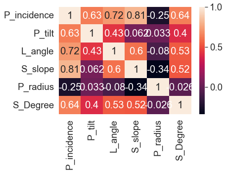

```python
sns.heatmap(data=union[['P_incidence','P_tilt','L_angle','S_slope','P_radius','S_Degree','Class']].corr(),annot=True)
plt.figure(figsize=(8,50));
```

3.B. Share insights on correlation

3.B.1. Features having stronger correlation with correlation value

```python
union.corr()
```

|  | P_incidence | P_tilt | L_angle | S_slope | P_radius | S_Degree |
| --- | --- | --- | --- | --- | --- | --- |
| P_incidence | 1.000000 | 0.629199 | 0.717282 | 0.814960 | -0.247467 | 0.638743 |
| P_tilt | 0.629199 | 1.000000 | 0.432764 | 0.062345 | 0.032668 | 0.397862 |
| L_angle | 0.717282 | 0.432764 | 1.000000 | 0.598387 | -0.080344 | 0.533667 |
| S_slope | 0.814960 | 0.062345 | 0.598387 | 1.000000 | -0.342128 | 0.523557 |
| P_radius | -0.247467 | 0.032668 | -0.080344 | -0.342128 | 1.000000 | -0.026065 |
| S_Degree | 0.638743 | 0.397862 | 0.533667 | 0.523557 | -0.026065 | 1.000000 |

```python
union.corr()>1
```

|  | P_incidence | P_tilt | L_angle | S_slope | P_radius | S_Degree |
| --- | --- | --- | --- | --- | --- | --- |
| P_incidence | False | False | False | False | False | False |
| P_tilt | False | False | False | False | False | False |
| L_angle | False | False | False | False | False | False |
| S_slope | False | False | False | False | False | False |
| P_radius | False | False | False | False | False | False |
| S_Degree | False | False | False | False | False | False |

3.B.2. Features having weaker correlation with correlation value

```python
union.corr()
```

|  | P_incidence | P_tilt | L_angle | S_slope | P_radius | S_Degree |
| --- | --- | --- | --- | --- | --- | --- |
| P_incidence | 1.000000 | 0.629199 | 0.717282 | 0.814960 | -0.247467 | 0.638743 |
| P_tilt | 0.629199 | 1.000000 | 0.432764 | 0.062345 | 0.032668 | 0.397862 |
| L_angle | 0.717282 | 0.432764 | 1.000000 | 0.598387 | -0.080344 | 0.533667 |
| S_slope | 0.814960 | 0.062345 | 0.598387 | 1.000000 | -0.342128 | 0.523557 |
| P_radius | -0.247467 | 0.032668 | -0.080344 | -0.342128 | 1.000000 | -0.026065 |
| S_Degree | 0.638743 | 0.397862 | 0.533667 | 0.523557 | -0.026065 | 1.000000 |

```python
union.corr()<1
```

|  | P_incidence | P_tilt | L_angle | S_slope | P_radius | S_Degree |
| --- | --- | --- | --- | --- | --- | --- |
| P_incidence | False | True | True | True | True | True |
| P_tilt | True | False | True | True | True | True |
| L_angle | True | True | False | True | True | True |
| S_slope | True | True | True | False | True | True |
| P_radius | True | True | True | True | False | True |
| S_Degree | True | True | True | True | True | False |

3.C. Visualize a pairplot with 3 classes distinguished by colors and share insights

```python
union['Class']=union['Class'].astype('category')
```

```python
union['Class'].nunique()
```

```
3
```

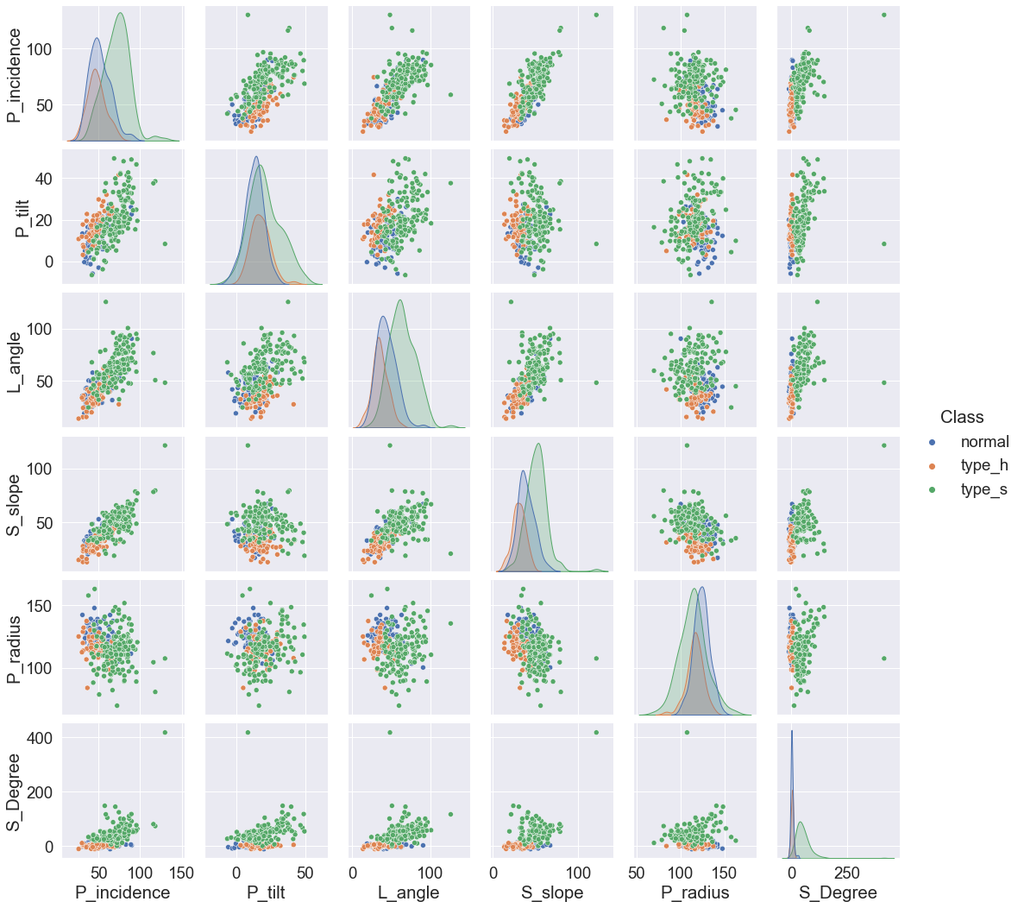

```python
sns.pairplot(union,hue='Class');
```

It is evident that type_s class is more compared to other two

normal class has higher values compared to Type_h

3.D. Visualize a jointplot for ‘P_incidence’ and ‘S_slope’ and share insights.

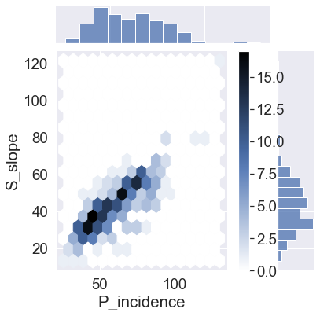

```python
sns.jointplot(data=union,x='P_incidence',y='S_slope',kind='hex')
plt.colorbar();
```

3.E. Visualize a boxplot to check distribution of the features and share insights

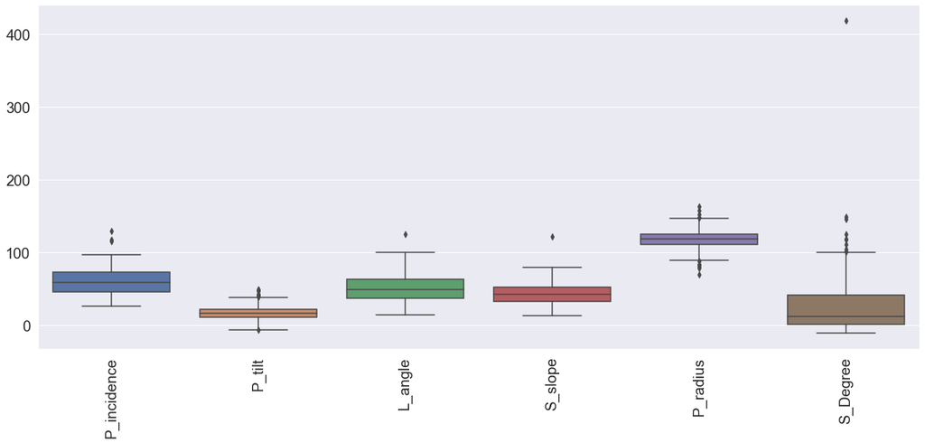

```python
plt.figure(figsize=(20,8))
sns.boxplot(data=union)
plt.xticks(rotation=90)
plt.show();
```

# 4. Model Building:

4.A.Split data into X and Y

```python
from sklearn.model_selection import train_test_split
from sklearn.neighbors import KNeighborsClassifier
from sklearn.metrics import accuracy_score, confusion_matrix
from sklearn.linear_model import LogisticRegression
from sklearn.naive_bayes import GaussianNB
from sklearn.svm import SVC
from sklearn import metrics
from sklearn.metrics import classification_report
from sklearn import model_selection
```

```python
# Arrange data into independent variables and dependent variables
X=union.drop(columns='Class')
y=union['Class']
```

4.B. Split data into train and test with 80:20 proportion.

```python
X_train, X_test, y_train, y_test = train_test_split(X, y, test_size=0.20, random_state=10)
```

4.C. Train a Supervised Learning Classification base model using KNN classifier

```python
KNN = KNeighborsClassifier(n_neighbors= 5 , metric = 'minkowski' )
KNN.fit(X_train, y_train)
predicted_labels = KNN.predict(X_test)
```

```python
print('Accuracy on Training data:',KNN.score(X_train, y_train) )
print('Accuracy on Test data:',KNN.score(X_test, y_test) )
```

```
Accuracy on Training data: 0.9153225806451613
Accuracy on Test data: 0.7096774193548387
```

4.D. Print all the possible performance metrics for both train and test data

```python
print(metrics.classification_report(y_test, predicted_labels))
```

```
              precision    recall  f1-score   support

      normal       0.53      0.47      0.50        17
      type_h       0.45      0.60      0.51        15
      type_s       1.00      0.90      0.95        30

    accuracy                           0.71        62
   macro avg       0.66      0.66      0.65        62
weighted avg       0.74      0.71      0.72        62
```

# 5. Performance Improvement:

5.A. Experiment with various parameters to improve performance of the base model

1. Determine the value of K.

```python
train_score=[]
test_score=[]
for k in range(1,51):
    KNN = KNeighborsClassifier(n_neighbors= k , metric = 'minkowski' )
    KNN.fit(X_train, y_train)
    train_score.append(KNN.score(X_train, y_train))
    test_score.append(KNN.score(X_test, y_test))
```

```python
k=[1,3,5,7,9,11,13,15,17,19]
for i in k:
    KNN = KNeighborsClassifier(n_neighbors=i, metric = 'euclidean' ) #Building knn with 5 neighbors
    KNN.fit(X_train, y_train)
    predicted_labels = KNN.predict(X_test)
    print('Accuracy on Training data for k {} is {}:'.format(i,KNN.score(X_train, y_train)))
    print('Accuracy on Test data for k {} is {}:'.format(i,KNN.score(X_test, y_test)))
    print("classification  Matrix:\n",classification_report(y_test,predicted_labels))
```

```
Accuracy on Training data for k 1 is 1.0:
Accuracy on Test data for k 1 is 0.7419354838709677:
classification  Matrix:
               precision    recall  f1-score   support

      normal       0.57      0.47      0.52        17
      type_h       0.53      0.67      0.59        15
      type_s       0.97      0.93      0.95        30

    accuracy                           0.74        62
   macro avg       0.69      0.69      0.68        62
weighted avg       0.75      0.74      0.74        62

Accuracy on Training data for k 3 is 0.9354838709677419:
Accuracy on Test data for k 3 is 0.7419354838709677:
classification  Matrix:
               precision    recall  f1-score   support

      normal       0.57      0.47      0.52        17
      type_h       0.53      0.67      0.59        15
      type_s       0.97      0.93      0.95        30

    accuracy                           0.74        62
   macro avg       0.69      0.69      0.68        62
weighted avg       0.75      0.74      0.74        62

Accuracy on Training data for k 5 is 0.9153225806451613:
Accuracy on Test data for k 5 is 0.7096774193548387:
classification  Matrix:
               precision    recall  f1-score   support

      normal       0.53      0.47      0.50        17
      type_h       0.45      0.60      0.51        15
      type_s       1.00      0.90      0.95        30

    accuracy                           0.71        62
   macro avg       0.66      0.66      0.65        62
weighted avg       0.74      0.71      0.72        62

Accuracy on Training data for k 7 is 0.9032258064516129:
```

[output cut: 74 more lines]

```
   macro avg       0.70      0.70      0.69        62
weighted avg       0.76      0.74      0.75        62

Accuracy on Training data for k 19 is 0.875:
Accuracy on Test data for k 19 is 0.7741935483870968:
classification  Matrix:
               precision    recall  f1-score   support

      normal       0.58      0.65      0.61        17
      type_h       0.62      0.67      0.65        15
      type_s       1.00      0.90      0.95        30

    accuracy                           0.77        62
   macro avg       0.73      0.74      0.73        62
weighted avg       0.79      0.77      0.78        62
```

# Part B

```python
import numpy             as np
import pandas            as pd
import scipy.stats       as stats
import matplotlib.pyplot as plt
import seaborn           as sns
```

# 1. Data Understanding and Preparation:

1.A. Read both the Datasets ‘Data1’ and ‘Data 2’ as DataFrame and store them into two separate variables

```python
a=pd.read_csv("C:\\Users\\HARITHA\\Pictures\\Great Learning project\\Supervised Learning\\Data1.csv")
b=pd.read_csv("C:\\Users\\HARITHA\\Pictures\\Great Learning project\\Supervised Learning\\Data2.csv")
```

1.B. Print shape and Column Names and DataTypes of both the Dataframes.

```python
a.shape
```

```
(5000, 8)
```

```python
b.shape
```

```
(5000, 7)
```

1.C. Merge both the Dataframes on ‘ID’ feature to form a single DataFrame

```python
df=a.merge(b,left_on='ID',right_on='ID')
```

```python
df.shape
```

```
(5000, 14)
```

1.D. Change Datatype of below features to ‘Object’

‘CreditCard’, ‘InternetBanking’, ‘FixedDepositAccount’, ‘Security’, ‘Level’, ‘HiddenScore’.

```python
df.dtypes
```

```
ID                       int64
Age                      int64
CustomerSince            int64
HighestSpend             int64
ZipCode                  int64
HiddenScore              int64
MonthlyAverageSpend    float64
Level                    int64
Mortgage                 int64
Security                 int64
FixedDepositAccount      int64
InternetBanking          int64
CreditCard               int64
LoanOnCard             float64
dtype: object
```

```python
col=['HiddenScore','Level','Security','FixedDepositAccount', 'InternetBanking', 'CreditCard', 'LoanOnCard']
for i in col:
    df[i]=df[i].astype('category')
```

```python
df.dtypes
```

```
ID                        int64
Age                       int64
CustomerSince             int64
HighestSpend              int64
ZipCode                   int64
HiddenScore            category
MonthlyAverageSpend     float64
Level                  category
Mortgage                  int64
Security               category
FixedDepositAccount    category
InternetBanking        category
CreditCard             category
LoanOnCard             category
dtype: object
```

# 2. Data Exploration and Analysis:

2.A. Visualize distribution of Target variable ‘LoanOnCard’ and clearly share insights

```python
df.describe()
```

|  | ID | Age | CustomerSince | HighestSpend | ZipCode | MonthlyAverageSpend | Mortgage |
| --- | --- | --- | --- | --- | --- | --- | --- |
| count | 5000.000000 | 5000.000000 | 5000.000000 | 5000.000000 | 5000.000000 | 5000.000000 | 5000.000000 |
| mean | 2500.500000 | 45.338400 | 20.104600 | 73.774200 | 93152.503000 | 1.937938 | 56.498800 |
| std | 1443.520003 | 11.463166 | 11.467954 | 46.033729 | 2121.852197 | 1.747659 | 101.713802 |
| min | 1.000000 | 23.000000 | -3.000000 | 8.000000 | 9307.000000 | 0.000000 | 0.000000 |
| 25% | 1250.750000 | 35.000000 | 10.000000 | 39.000000 | 91911.000000 | 0.700000 | 0.000000 |
| 50% | 2500.500000 | 45.000000 | 20.000000 | 64.000000 | 93437.000000 | 1.500000 | 0.000000 |
| 75% | 3750.250000 | 55.000000 | 30.000000 | 98.000000 | 94608.000000 | 2.500000 | 101.000000 |
| max | 5000.000000 | 67.000000 | 43.000000 | 224.000000 | 96651.000000 | 10.000000 | 635.000000 |

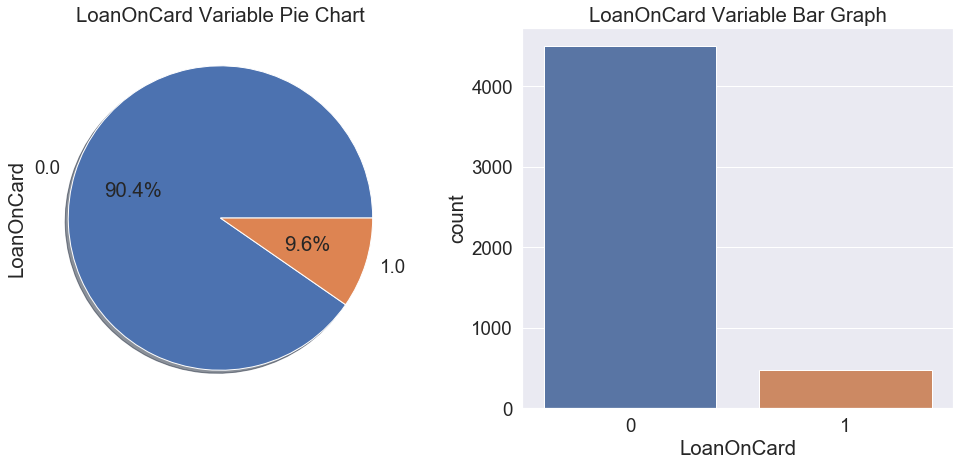

```python
f,axes=plt.subplots(1,2,figsize=(17,7))
df['LoanOnCard'].value_counts().plot.pie(autopct='%1.1f%%',ax=axes[0],shadow=True)
sns.countplot(data=df,x='LoanOnCard',ax=axes[1],order=[0,1])
axes[0].set_title('LoanOnCard Variable Pie Chart')
axes[1].set_title('LoanOnCard Variable Bar Graph')
plt.show()
```

- We can see 90% of people does not have loan on credit card

# Hidden score vs Loan on card

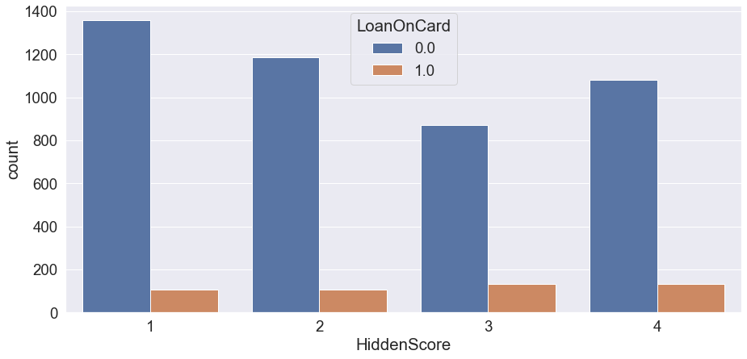

```python
plt.figure(figsize=(15,7))
sns.countplot(data=df,x='HiddenScore',hue='LoanOnCard');
```

Hidden score is more for non-loan holders

# Level vs Loan on card

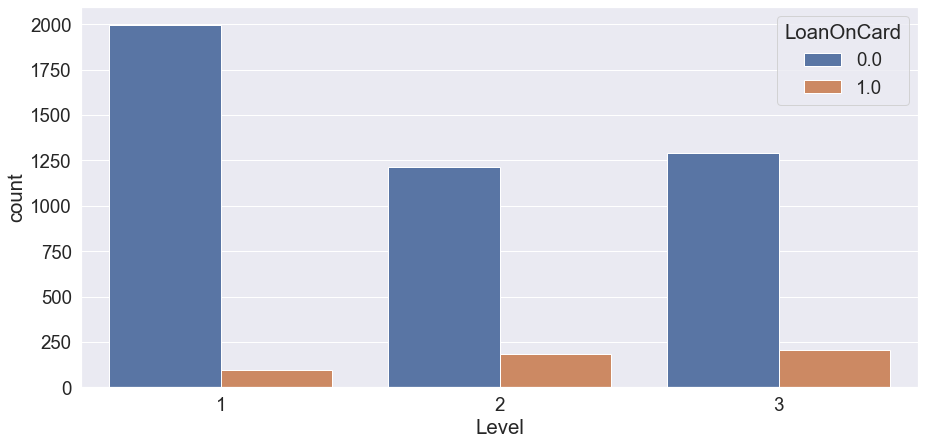

```python
plt.figure(figsize=(15,7))
sns.countplot(data=df,x='Level',hue='LoanOnCard');
```

- Level 1 has minimum number of loan holders
- Loan holders in Level 2 and 3 are nearly equal

# Security vs Loan on card

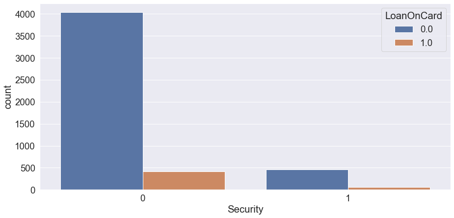

```python
plt.figure(figsize=(15,7))
sns.countplot(data=df,x='Security',hue='LoanOnCard');
```

is surprisingly to see more customers those who have loan does not have any security

Security of loan holders are very less

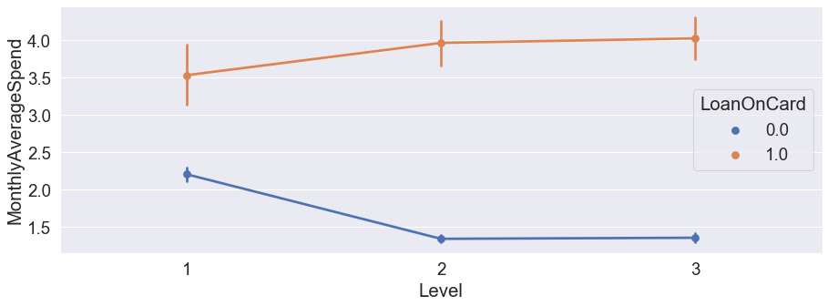

```python
plt.figure(figsize=(15,5))
sns.pointplot(x="Level", y="MonthlyAverageSpend", hue = 'LoanOnCard',  data=df)
plt.show();
```

2.B. Check the percentage of missing values and impute if required.

```python
df.sample(10)
```

|  | ID | Age | CustomerSince | HighestSpend | ZipCode | HiddenScore | MonthlyAverageSpend | Level | Mortgage | Security | FixedDepositAccount | InternetBanking | CreditCard | LoanOnCard |
| --- | --- | --- | --- | --- | --- | --- | --- | --- | --- | --- | --- | --- | --- | --- |
| 435 | 436 | 52 | 26 | 80 | 94709 | 3 | 0.80 | 1 | 0 | 0 | 0 | 0 | 0 | 0.0 |
| 3112 | 3113 | 56 | 32 | 65 | 92677 | 2 | 3.20 | 3 | 0 | 0 | 0 | 1 | 0 | 0.0 |
| 2365 | 2366 | 43 | 18 | 22 | 91311 | 2 | 0.30 | 2 | 0 | 0 | 0 | 0 | 0 | 0.0 |
| 4993 | 4994 | 45 | 21 | 218 | 91801 | 2 | 6.67 | 1 | 0 | 0 | 0 | 1 | 0 | 0.0 |
| 3273 | 3274 | 40 | 15 | 180 | 90095 | 1 | 4.10 | 1 | 0 | 0 | 0 | 0 | 0 | 0.0 |
| 149 | 150 | 48 | 22 | 42 | 93955 | 3 | 2.20 | 2 | 0 | 0 | 0 | 0 | 0 | 0.0 |
| 760 | 761 | 29 | 3 | 52 | 92122 | 3 | 1.10 | 2 | 0 | 0 | 0 | 1 | 0 | 0.0 |
| 4707 | 4708 | 59 | 35 | 91 | 95008 | 2 | 1.60 | 1 | 0 | 1 | 0 | 0 | 1 | 0.0 |
| 2885 | 2886 | 57 | 31 | 113 | 91711 | 4 | 0.60 | 3 | 327 | 0 | 0 | 1 | 0 | 1.0 |
| 2898 | 2899 | 27 | 1 | 140 | 91711 | 1 | 5.90 | 2 | 175 | 1 | 1 | 1 | 0 | 1.0 |

```python
df.isnull().sum()
```

```
ID                      0
Age                     0
CustomerSince           0
HighestSpend            0
ZipCode                 0
HiddenScore             0
MonthlyAverageSpend     0
Level                   0
Mortgage                0
Security                0
FixedDepositAccount     0
InternetBanking         0
CreditCard              0
LoanOnCard             20
dtype: int64
```

```python
df.drop('ID',axis=1,inplace=True)
```

```python
df.dropna(axis=0,inplace=True)
```

```python
df.isnull().sum()
```

```
Age                    0
CustomerSince          0
HighestSpend           0
ZipCode                0
HiddenScore            0
MonthlyAverageSpend    0
Level                  0
Mortgage               0
Security               0
FixedDepositAccount    0
InternetBanking        0
CreditCard             0
LoanOnCard             0
dtype: int64
```

Id column is not useful in model building so dropping that feature

2.C. Check for unexpected values in each categorical variable and impute with best suitable value

```python
col=['HighestSpend','MonthlyAverageSpend','Mortgage']
```

```python
for c in col:
    #getting upper lower quartile values
    q25,q75=np.percentile(df[c],25),np.percentile(df[c],75)
    IQR=q75-q25
    Threshold=IQR*1.5
    lower,upper=q25-Threshold,q75+Threshold
    Outliers=[i for i in df[c] if i < lower or i > upper]
    print('{} Total Number of outliers in {} Before Imputing : {}'.format('\033[1m',c,len(Outliers)))
    print('\n')
    #taking mean of a column without considering outliers
    df_include = df.loc[(df[c] >= lower) & (df[c] <= upper)]
    mean=int(df_include[c].mean())
    print('{} Mean of {} is {}'.format('\033[1m',c,mean))
    print('\n')
    #imputing outliers with mean
    df[c]=np.where(df[c]>upper,mean,df[c])
    df[c]=np.where(df[c]<lower,mean,df[c])
    Outliers=[i for i in df[c] if i < lower or i > upper]
    print('{} Total Number of outliers in {} After Imputing 0000000000: {}'.format('\033[1m',c,len(Outliers)))
    print('\n')
```

```
 Total Number of outliers in HighestSpend Before Imputing : 96


 Mean of HighestSpend is 71


 Total Number of outliers in HighestSpend After Imputing 0000000000: 0


 Total Number of outliers in MonthlyAverageSpend Before Imputing : 324


 Mean of MonthlyAverageSpend is 1


 Total Number of outliers in MonthlyAverageSpend After Imputing 0000000000: 0


 Total Number of outliers in Mortgage Before Imputing : 291


 Mean of Mortgage is 38


 Total Number of outliers in Mortgage After Imputing 0000000000: 0
```

# 3. Data Preparation and model building:

3.A. Split data into X and Y.

```python
df.sample(5)
```

|  | Age | CustomerSince | HighestSpend | ZipCode | HiddenScore | MonthlyAverageSpend | Level | Mortgage | Security | FixedDepositAccount | InternetBanking | CreditCard | LoanOnCard |
| --- | --- | --- | --- | --- | --- | --- | --- | --- | --- | --- | --- | --- | --- |
| 4143 | 55 | 31 | 20 | 94720 | 2 | 0.3 | 1 | 0 | 0 | 0 | 1 | 0 | 0.0 |
| 3094 | 50 | 23 | 19 | 90272 | 1 | 0.5 | 2 | 104 | 0 | 0 | 0 | 1 | 0.0 |
| 2932 | 41 | 16 | 154 | 92407 | 1 | 1.0 | 1 | 0 | 0 | 0 | 0 | 1 | 0.0 |
| 1078 | 51 | 27 | 39 | 92709 | 2 | 0.8 | 1 | 182 | 0 | 0 | 0 | 1 | 0.0 |
| 3136 | 60 | 34 | 65 | 95354 | 3 | 2.2 | 3 | 94 | 1 | 1 | 0 | 1 | 0.0 |

```python
X=df.drop(columns='LoanOnCard')
y=df['LoanOnCard']
```

3.B. Split data into train and test. Keep 25% data reserved for testing.

```python
X_train, X_test, y_train, y_test = train_test_split(X, y, test_size=0.25, random_state=10)
```

```python
X_train
```

|  | Age | CustomerSince | HighestSpend | ZipCode | HiddenScore | MonthlyAverageSpend | Level | Mortgage | Security | FixedDepositAccount | InternetBanking | CreditCard |
| --- | --- | --- | --- | --- | --- | --- | --- | --- | --- | --- | --- | --- |
| 740 | 52 | 27 | 71 | 90266 | 1 | 1.0 | 1 | 0 | 0 | 0 | 0 | 0 |
| 368 | 63 | 37 | 30 | 92054 | 2 | 1.0 | 3 | 159 | 0 | 0 | 1 | 0 |
| 2296 | 27 | 3 | 82 | 94305 | 2 | 0.2 | 1 | 0 | 0 | 0 | 0 | 1 |
| 2788 | 45 | 20 | 30 | 96003 | 1 | 0.1 | 1 | 0 | 0 | 0 | 1 | 0 |
| 1143 | 33 | 7 | 120 | 94022 | 1 | 3.2 | 3 | 0 | 0 | 0 | 1 | 0 |
| ... | ... | ... | ... | ... | ... | ... | ... | ... | ... | ... | ... | ... |
| 1200 | 36 | 12 | 22 | 92507 | 4 | 1.0 | 1 | 91 | 1 | 0 | 1 | 0 |
| 3461 | 57 | 27 | 64 | 92007 | 3 | 2.0 | 3 | 142 | 0 | 0 | 1 | 0 |
| 1364 | 44 | 19 | 69 | 92129 | 4 | 0.4 | 1 | 0 | 0 | 0 | 0 | 0 |
| 4643 | 33 | 7 | 35 | 95616 | 4 | 0.8 | 1 | 0 | 0 | 0 | 1 | 0 |
| 1309 | 38 | 14 | 71 | 95136 | 4 | 2.0 | 3 | 0 | 0 | 0 | 0 | 0 |

3735 rows × 12 columns

```python
logit = LogisticRegression()
logit.fit(X_train, y_train)
logit_pred = logit.predict(X_test)

print('Accuracy on Training data:',logit.score(X_train, y_train) )
print('Accuracy on Test data:',logit.score(X_test, y_test) )
```

```
Accuracy on Training data: 0.908433734939759
Accuracy on Test data: 0.9036144578313253
```

```python
from sklearn.model_selection import train_test_split
# spliting into 75:25 ration
X__train, X__test, y__train, y__test = train_test_split(X, y, test_size = 0.25, random_state = 0)
# describes information about train and test set
print("Number of transactions X__train dataset: ", X__train.shape)
print("Number of transactions y__train dataset: ", y__train.shape)
print("Number of transactions X__test dataset: ", X__test.shape)
print("Number of transactions y__test dataset: ", y__test.shape)
```

```
Number of transactions X__train dataset:  (3735, 12)
Number of transactions y__train dataset:  (3735,)
Number of transactions X__test dataset:  (1245, 12)
Number of transactions y__test dataset:  (1245,)
```

3.D.Print evaluation metrics for the model and clearly share insights

```python
# logistic regression object
lrr = LogisticRegression()
# train the model on train set
lrr.fit(X__train, y__train.ravel())
predictions = lrr.predict(X__test)
# print classification report
print(classification_report(y__test, predictions))
```

```
              precision    recall  f1-score   support

         0.0       0.94      0.97      0.96      1135
         1.0       0.56      0.39      0.46       110

    accuracy                           0.92      1245
   macro avg       0.75      0.68      0.71      1245
weighted avg       0.91      0.92      0.91      1245
```

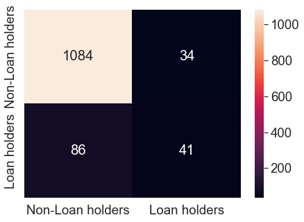

```python
cm = confusion_matrix(y_test, logit_pred, labels=[0, 1])

df_cm = pd.DataFrame(cm, index = [i for i in ["Non-Loan holders","Loan holders"]],
                  columns = [i for i in ["Non-Loan holders","Loan holders"]])
plt.figure(figsize = (7,5))
sns.heatmap(df_cm, annot=True ,fmt='g')
plt.show()
```

```python
from sklearn.neighbors import KNeighborsClassifier
from sklearn.metrics import accuracy_score
from sklearn.metrics import recall_score

# instantiate learning model (k = 3)
knn = KNeighborsClassifier(n_neighbors = 3)

# fitting the model
knn.fit(X_train, y_train)

# predict the response
y_pred = knn.predict(X_test)

# evaluate accuracy
print(accuracy_score(y_test, y_pred))

# instantiate learning model (k = 5)
knn = KNeighborsClassifier(n_neighbors=5)

# fitting the model
knn.fit(X_train, y_train)

# predict the response
y_pred = knn.predict(X_test)

# evaluate accuracy
print(accuracy_score(y_test, y_pred))

# instantiate learning model (k = 9)
knn = KNeighborsClassifier(n_neighbors=9)

# fitting the model
knn.fit(X_train, y_train)

# predict the response
y_pred = knn.predict(X_test)

# evaluate accuracy
print(accuracy_score(y_test, y_pred))
```

```
0.8899598393574297
0.9036144578313253
0.8995983935742972
```

```python
print(accuracy_score(y_test,y_pred))
pd.crosstab(y_test,y_pred)
```

```
0.8995983935742972
```

| col_0 LoanOnCard | 0.0 | 1.0 |
| --- | --- | --- |
| 0.0 | 1100 | 18 |
| 1.0 | 107 | 20 |

```python
from sklearn.metrics import classification_report
print(confusion_matrix(y_test,y_pred))
print(classification_report(y_test,y_pred))
```

```
[[1100   18]
 [ 107   20]]
              precision    recall  f1-score   support

         0.0       0.91      0.98      0.95      1118
         1.0       0.53      0.16      0.24       127

    accuracy                           0.90      1245
   macro avg       0.72      0.57      0.59      1245
weighted avg       0.87      0.90      0.87      1245
```

```python
# Importing all necessary libraries
from sklearn.metrics import precision_score

# Calculating the precision score of classifier
print(f"Precision Score of the classifier is: {precision_score(y_test, y_pred)}")
```

```
Precision Score of the classifier is: 0.5263157894736842
```

- The Precision Score of the classifier is: 0.52

```python
# Importing all necessary libraries
from sklearn.metrics import f1_score

# Calculating the F1 score of classifier
print(f"F1 Score of the classifier is: {f1_score(y_test,y_pred)}")
```

```
F1 Score of the classifier is: 0.24242424242424238
```

- The F1 Score of the classifier is: 0.24

```python
from sklearn.metrics import precision_recall_curve
from sklearn.metrics import plot_precision_recall_curve
from sklearn.metrics import precision_score
from sklearn.metrics import recall_score

#calculating precision and reall
precision = precision_score(y_test,y_pred)
recall = recall_score(y_test,y_pred)

print('Precision: ',precision)
print('Recall: ',recall)
```

```
Precision:  0.5263157894736842
Recall:  0.15748031496062992
```

- The precision is 0.52 and Recall is 0.15

```python
#Build the logistic regression model
logreg = LogisticRegression(max_iter=1000)
```

```python
logreg.fit(X_train, y_train.values.ravel())
```

```
LogisticRegression(max_iter=1000)
```

```python
#Predict for test set
pred_test = logreg.predict(X_test)
```

```python
pred_test
```

```
array([1., 0., 0., ..., 0., 0., 0.])
```

```python
#Predict for train set
pred_train = logreg.predict(X_train)
```

```python
from sklearn.metrics import accuracy_score
test_accuracy=accuracy_score(y_test, pred_test)

print('Test Accuracy: ',np.round(test_accuracy,2))
```

```
Test Accuracy:  0.9
```

```python
train_accuracy=accuracy_score(y_train, pred_train)

print('Test Accuracy: ',np.round(train_accuracy,2))
```

```
Test Accuracy:  0.91
```

# Confusion matrix:

```python
from sklearn.metrics import classification_report,confusion_matrix
mat_train = confusion_matrix(y_train,pred_train)

print("confusion matrix_train_data = \n",mat_train)
```

```
confusion matrix_train_data =
 [[3292   90]
 [ 252  101]]
```

```python
mat_test = confusion_matrix(y_test,pred_test)
print("confusion matrix_test_data = \n",mat_test)
```

```
confusion matrix_test_data =
 [[1084   34]
 [  86   41]]
```

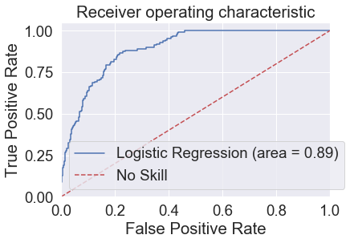

```python
#AUC ROC curve
from sklearn.metrics import roc_auc_score
from sklearn.metrics import roc_curve

logit_roc_auc = roc_auc_score(y_test, logreg.predict_proba(X_test)[:,1])
fpr, tpr, thresholds = roc_curve(y_test, logreg.predict_proba(X_test)[:,1])
plt.figure()
plt.plot(fpr, tpr, label='Logistic Regression (area = %0.2f)' % logit_roc_auc)
plt.plot([0, 1], [0, 1],'r--',label='No Skill')
plt.xlim([0.0, 1.0])
plt.ylim([0.0, 1.05])
plt.xlabel('False Positive Rate')
plt.ylabel('True Positive Rate')
plt.title('Receiver operating characteristic')
plt.legend(loc="best")
plt.savefig('Log_ROC')
plt.show()
```

- Sensitivity = TruePositive / (TruePositive + FalseNegative)
- Specificity = TrueNegative / (FalsePositive + TrueNegative)
- Sensitivity = True Positive Rate
- Specificity = 1 – False Positive Rate
- G-Mean = sqrt(Sensitivity * Specificity)

```
Best Threshold=0.074220, G-Mean=0.824
```

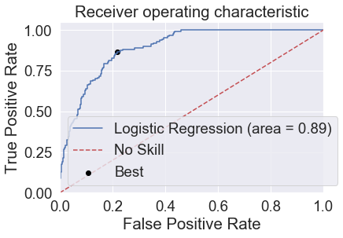

```python
#AUC ROC curve
from sklearn.metrics import roc_auc_score
from sklearn.metrics import roc_curve
# roc curve for logistic regression model with optimal threshold
from numpy import sqrt
from numpy import argmax

logit_roc_auc = roc_auc_score(y_test, logreg.predict_proba(X_test)[:,1])
fpr, tpr, thresholds = roc_curve(y_test, logreg.predict_proba(X_test)[:,1])
# calculate the g-mean for each threshold
gmeans = sqrt(tpr * (1-fpr))
# locate the index of the largest g-mean
ix = argmax(gmeans)
print('Best Threshold=%f, G-Mean=%.3f' % (thresholds[ix], gmeans[ix]))
plt.figure()
plt.plot(fpr, tpr, label='Logistic Regression (area = %0.2f)' % logit_roc_auc)
plt.plot([0, 1], [0, 1],'r--',label='No Skill')
plt.scatter(fpr[ix], tpr[ix], marker='o', color='black', label='Best')
plt.xlim([0.0, 1.0])
plt.ylim([0.0, 1.05])
plt.xlabel('False Positive Rate')
plt.ylabel('True Positive Rate')
plt.title('Receiver operating characteristic')
plt.legend(loc="best")
plt.savefig('Log_ROC')
plt.show()
```

- The Best Threshold=0.074220, G-Mean=0.824

```
Best Threshold=0.798245, F-Score=nan
```

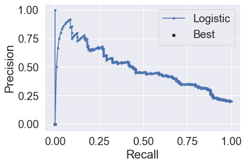

```python
from sklearn.metrics import precision_recall_curve
yhat=logreg.predict_proba(X_test)[:,1]
# calculate roc curves
precision, recall, thresholds = precision_recall_curve(y_test, yhat)
# convert to f score
fscore = (2 * precision * recall) / (precision + recall)
# locate the index of the largest f score
ix = argmax(fscore)
print('Best Threshold=%f, F-Score=%.3f' % (thresholds[ix], fscore[ix]))
# plot the roc curve for the model
# no_skill = len(y_test[y_test==1]) / len(y_test)
# plt.plot([0,1], [no_skill,no_skill], linestyle='--', label='No Skill')
plt.plot(recall, precision, marker='.', label='Logistic')
plt.scatter(recall[ix], precision[ix], marker='*', color='black', label='Best')
# axis labels
plt.xlabel('Recall')
plt.ylabel('Precision')
plt.legend()
# show the plot
plt.show()
```

- The Best Threshold=0.798245, F-Score=nan

3.E. Balance the data using the right balancing technique.

i. Check distribution of the target variable

```python
y_train.value_counts()
```

```
0.0    3382
1.0     353
Name: LoanOnCard, dtype: int64
```

```python
y.value_counts()
```

```
0.0    4500
1.0     480
Name: LoanOnCard, dtype: int64
```

# OverSampling

```python
from sklearn.model_selection import train_test_split

# split into 80:20 ration
X_train, X_test, y_train, y_test = train_test_split(X, y, test_size = 0.20, random_state = 10)

# describes info about train and test set
print("Number transactions X_train dataset: ", X_train.shape)
print("Number transactions y_train dataset: ", y_train.shape)
print("Number transactions X_test dataset: ", X_test.shape)
print("Number transactions y_test dataset: ", y_test.shape)
```

```
Number transactions X_train dataset:  (3984, 12)
Number transactions y_train dataset:  (3984,)
Number transactions X_test dataset:  (996, 12)
Number transactions y_test dataset:  (996,)
```

```python
print("Before OverSampling, counts of label '1': {}".format(sum(y_train == 1)))
print("Before OverSampling, counts of label '0': {} \n".format(sum(y_train == 0)))

# import SMOTE module from imblearn library
# pip install imblearn (if you don't have imblearn in your system)
from imblearn.over_sampling import SMOTE
sm = SMOTE(random_state = 2)
X_train_res, y_train_res = sm.fit_sample(X_train, y_train.ravel())

print('After OverSampling, the shape of train_X: {}'.format(X_train_res.shape))
print('After OverSampling, the shape of train_y: {} \n'.format(y_train_res.shape))

print("After OverSampling, counts of label '1': {}".format(sum(y_train_res == 1)))
print("After OverSampling, counts of label '0': {}".format(sum(y_train_res == 0)))
```

```
Before OverSampling, counts of label '1': 379
Before OverSampling, counts of label '0': 3605

After OverSampling, the shape of train_X: (7210, 12)
After OverSampling, the shape of train_y: (7210,)

After OverSampling, counts of label '1': 3605
After OverSampling, counts of label '0': 3605
```

```python
# logistic regression object
lr = LogisticRegression()

# train the model on train set
lr.fit(X_train, y_train.ravel())

predictions = lr.predict(X_test)

# print classification report
print(classification_report(y_test, predictions))
```

```
              precision    recall  f1-score   support

         0.0       0.93      0.97      0.95       895
         1.0       0.57      0.33      0.42       101

    accuracy                           0.91       996
   macro avg       0.75      0.65      0.68       996
weighted avg       0.89      0.91      0.90       996
```

```python
# Importing all necessary libraries
from sklearn.metrics import precision_score

# Calculating the precision score of classifier
print(f"Precision Score of the classifier is: {precision_score(y_test,predictions)}")
```

```
Precision Score of the classifier is: 0.5689655172413793
```

```python
# Importing all necessary libraries
from sklearn.metrics import f1_score

# Calculating the F1 score of classifier
print(f"F1 Score of the classifier is: {f1_score(y_test,predictions)}")
```

```
F1 Score of the classifier is: 0.4150943396226416
```

```python
#calculating precision and reall
precision = precision_score(y_test,predictions)
recall = recall_score(y_test,predictions)

print('Precision: ',precision)
print('Recall: ',recall)
```

```
Precision:  0.5689655172413793
Recall:  0.32673267326732675
```

```python
print(accuracy_score(y_test,predictions))
pd.crosstab(y_test,predictions)
```

```
0.9066265060240963
```

| col_0 LoanOnCard | 0.0 | 1.0 |
| --- | --- | --- |
| 0.0 | 870 | 25 |
| 1.0 | 68 | 33 |

# NearMiss Algorithm:

```python
print("Before Under sampling, count of the label '1': {}".format(sum(y_train == 1)))
print("Before Under sampling, count of the label '0': {} \n".format(sum(y_train == 0)))
# applying algo near miss
from imblearn.under_sampling import NearMiss
nr = NearMiss()
X__train_miss, y__train_miss = nr.fit_sample(X_train, y_train.ravel())
print('After Under sampling, the shape of the train_X: {}'.format(X_train_res.shape))
print('After Under sampling, the shape of the train_y: {} \n'.format(y_train_res.shape))
print("After Under sampling, counts of the label '1': {}".format(sum(y_train_res == 1)))
print("After Under sampling, counts of the label '0': {}".format(sum(y_train_res == 0)))
```

```
Before Under sampling, count of the label '1': 379
Before Under sampling, count of the label '0': 3605

After Under sampling, the shape of the train_X: (7210, 12)
After Under sampling, the shape of the train_y: (7210,)

After Under sampling, counts of the label '1': 3605
After Under sampling, counts of the label '0': 3605
```

```python
# train the model on train set
lrr = LogisticRegression()
lrr.fit(X__train_miss, y__train_miss.ravel())
predictions = lrr.predict (X__test)
# print classification report
print(classification_report(y__test, predictions))
```

```
              precision    recall  f1-score   support

         0.0       0.96      0.66      0.78      1135
         1.0       0.17      0.71      0.27       110

    accuracy                           0.67      1245
   macro avg       0.56      0.68      0.53      1245
weighted avg       0.89      0.67      0.74      1245
```

```python
# Importing all necessary libraries
from sklearn.metrics import precision_score

# Calculating the precision score of classifier
print(f"Precision Score of the classifier is: {precision_score(y__test,predictions)}")
```

```
Precision Score of the classifier is: 0.16846652267818574
```

```python
# Importing all necessary libraries
from sklearn.metrics import f1_score

# Calculating the F1 score of classifier
print(f"F1 Score of the classifier is: {f1_score(y__test,predictions)}")
```

```
F1 Score of the classifier is: 0.27225130890052357
```

```python
#calculating precision and reall
precision = precision_score(y__test,predictions)
recall = recall_score(y__test,predictions)

print('Precision: ',precision)
print('Recall: ',recall)
```

```
Precision:  0.16846652267818574
Recall:  0.7090909090909091
```

```python
print(accuracy_score(y__test,predictions))
pd.crosstab(y__test,predictions)
```

```
0.6650602409638554
```

| col_0 LoanOnCard | 0.0 | 1.0 |
| --- | --- | --- |
| 0.0 | 750 | 385 |
| 1.0 | 32 | 78 |

# RandomForestClassifier :

```python
from sklearn.ensemble import RandomForestClassifier
classifier=RandomForestClassifier()
classifier.fit(X_train,y_train)
```

```
RandomForestClassifier()
```

```python
y_pred=classifier.predict(X_test)
print(confusion_matrix(y_test,y_pred))
print(accuracy_score(y_test,y_pred))
print(classification_report(y_test,y_pred))
```

```
[[893   2]
 [ 16  85]]
0.9819277108433735
              precision    recall  f1-score   support

         0.0       0.98      1.00      0.99       895
         1.0       0.98      0.84      0.90       101

    accuracy                           0.98       996
   macro avg       0.98      0.92      0.95       996
weighted avg       0.98      0.98      0.98       996
```

3.F. Again train the same previous model on balanced data.

```python
X_train.info()
```

```
<class 'pandas.core.frame.DataFrame'>
Int64Index: 3984 entries, 4910 to 1309
Data columns (total 12 columns):
 #   Column               Non-Null Count  Dtype
---  ------               --------------  -----
 0   Age                  3984 non-null   int64
 1   CustomerSince        3984 non-null   int64
 2   HighestSpend         3984 non-null   int64
 3   ZipCode              3984 non-null   int64
 4   HiddenScore          3984 non-null   category
 5   MonthlyAverageSpend  3984 non-null   float64
 6   Level                3984 non-null   category
 7   Mortgage             3984 non-null   int64
 8   Security             3984 non-null   category
 9   FixedDepositAccount  3984 non-null   category
 10  InternetBanking      3984 non-null   category
 11  CreditCard           3984 non-null   category
dtypes: category(6), float64(1), int64(5)
memory usage: 241.9 KB
```

```python
X_train_res.info()
```

```
<class 'pandas.core.frame.DataFrame'>
RangeIndex: 7210 entries, 0 to 7209
Data columns (total 12 columns):
 #   Column               Non-Null Count  Dtype
---  ------               --------------  -----
 0   Age                  7210 non-null   int64
 1   CustomerSince        7210 non-null   int64
 2   HighestSpend         7210 non-null   int64
 3   ZipCode              7210 non-null   int64
 4   HiddenScore          4834 non-null   category
 5   MonthlyAverageSpend  7210 non-null   float64
 6   Level                5162 non-null   category
 7   Mortgage             7210 non-null   int64
 8   Security             6479 non-null   category
 9   FixedDepositAccount  5848 non-null   category
 10  InternetBanking      5759 non-null   category
 11  CreditCard           5788 non-null   category
dtypes: category(6), float64(1), int64(5)
memory usage: 381.0 KB
```

```python
# train the model on train set
lrr = LogisticRegression()
lrr.fit(X_train,y_train.ravel())
predictions = lrr.predict (X__test)
# print classification report
print(classification_report(y__test, predictions))
```

```
              precision    recall  f1-score   support

         0.0       0.94      0.97      0.96      1135
         1.0       0.55      0.38      0.45       110

    accuracy                           0.92      1245
   macro avg       0.74      0.68      0.70      1245
weighted avg       0.91      0.92      0.91      1245
```

3.G. Print evaluation metrics and clearly share differences observed.

```python
# Importing all necessary libraries
from sklearn.metrics import precision_score

# Calculating the precision score of classifier
print(f"Precision Score of the classifier is: {precision_score(y__test,predictions)}")
```

```
Precision Score of the classifier is: 0.5454545454545454
```

```python
# Importing all necessary libraries
from sklearn.metrics import f1_score

# Calculating the F1 score of classifier
print(f"F1 Score of the classifier is: {f1_score(y__test,predictions)}")
```

```
F1 Score of the classifier is: 0.4491978609625668
```

```python
#calculating precision and reall
precision = precision_score(y__test,predictions)
recall = recall_score(y__test,predictions)

print('Precision: ',precision)
print('Recall: ',recall)
```

```
Precision:  0.5454545454545454
Recall:  0.38181818181818183
```

```python
print(accuracy_score(y__test,predictions))
pd.crosstab(y__test,predictions)
```

```
0.9172690763052209
```

| col_0 LoanOnCard | 0.0 | 1.0 |
| --- | --- | --- |
| 0.0 | 1100 | 35 |
| 1.0 | 68 | 42 |

# 4. Performance Improvement:

4.A. Train a base model each for SVM, KNN. [4 Marks]

```python
from sklearn.svm import SVC
classifier = SVC(kernel = 'rbf', random_state = 0)
classifier.fit(X_train, y_train)
```

```
SVC(random_state=0)
```

```python
y_pred = classifier.predict(X__test)
y_pred
```

```
array([0., 0., 0., ..., 0., 0., 0.])
```

# SVM :

```python
from sklearn.svm import SVC

# Building a Support Vector Machine on train data
svc_model = SVC(C= .1, kernel='linear', gamma= 1)
svc_model.fit(X_train, y_train)

prediction = svc_model .predict(X_test)
```

```python
# check the accuracy on the training set
print(svc_model.score(X_train, y_train))
print(svc_model.score(X_test, y_test))
```

```
0.9141566265060241
0.9176706827309237
```

```python
# check the accuracy on the training set
print(svc_model.score(X__train, y__train))#balanced data
print(svc_model.score(X_test, y_test))
```

```
0.9119143239625167
0.9176706827309237
```

```python
print("Confusion Matrix:\n",confusion_matrix(prediction,y_test))
```

```
Confusion Matrix:
 [[880  67]
 [ 15  34]]
```

```python
svc_model = SVC(kernel='rbf')
svc_model.fit(X_train, y_train)
```

```
SVC()
```

```python
print(svc_model.score(X_train, y_train))
print(svc_model.score(X_test, y_test))
```

```
0.9048694779116466
0.8985943775100401
```

```python
#Building a Support Vector Machine on train data(changing the kernel)
svc_model  = SVC(kernel='poly')
svc_model.fit(X_train, y_train)

prediction = svc_model.predict(X_test)

print(svc_model.score(X_train, y_train))
print(svc_model.score(X_test, y_test))
```

```
0.9048694779116466
0.8985943775100401
```

```python
svc_model = SVC(kernel='sigmoid')
svc_model.fit(X_train, y_train)

prediction = svc_model.predict(X_test)

print(svc_model.score(X_train, y_train))
print(svc_model.score(X_test, y_test))
```

```
0.9046184738955824
0.8985943775100401
```

```python
gaussian=SVC(kernel='rbf')
gaussian.fit(X_train,y_train)
y__pred=gaussian.predict(X_test)
print('Accuracy-SVM : ',accuracy_score(y_test,y__pred))
```

```
Accuracy-SVM :  0.8985943775100401
```

# KNN :

```python
from sklearn.preprocessing import StandardScaler
st_x= StandardScaler()
x_train= st_x.fit_transform(X_train)
x_test= st_x.transform(X_test)
```

```python
#Fitting K-NN classifier to the training set
from sklearn.neighbors import KNeighborsClassifier
classifier= KNeighborsClassifier(n_neighbors=5, metric='minkowski', p=2 )
classifier.fit(x_train, y_train)
```

```
KNeighborsClassifier()
```

```python
y_pred= classifier.predict(X_test)
y_pred
```

[output not shown]

```python
#Creating the Confusion matrix
from sklearn.metrics import confusion_matrix,classification_report
cm=confusion_matrix(y_test,y_pred)
cm
```

```
array([[895,   0],
       [101,   0]], dtype=int64)
```

```python
print(f1_score(y_test,y_pred))
```

```
0.0
```

```python
print(classification_report(y_test,y_pred))
```

```
              precision    recall  f1-score   support

         0.0       0.90      1.00      0.95       895
         1.0       0.00      0.00      0.00       101

    accuracy                           0.90       996
   macro avg       0.45      0.50      0.47       996
weighted avg       0.81      0.90      0.85       996
```

4.B. Tune parameters for each of the models wherever required and finalize a model.

```python
import sklearn
sorted(sklearn.metrics.SCORERS.keys())
```

```
['accuracy',
 'adjusted_mutual_info_score',
 'adjusted_rand_score',
 'average_precision',
 'balanced_accuracy',
 'completeness_score',
 'explained_variance',
 'f1',
 'f1_macro',
 'f1_micro',
 'f1_samples',
 'f1_weighted',
 'fowlkes_mallows_score',
 'homogeneity_score',
 'jaccard',
 'jaccard_macro',
 'jaccard_micro',
 'jaccard_samples',
 'jaccard_weighted',
 'max_error',
 'mutual_info_score',
 'neg_brier_score',
 'neg_log_loss',
 'neg_mean_absolute_error',
 'neg_mean_absolute_percentage_error',
 'neg_mean_gamma_deviance',
 'neg_mean_poisson_deviance',
 'neg_mean_squared_error',
 'neg_mean_squared_log_error',
 'neg_median_absolute_error',
 'neg_root_mean_squared_error',
 'normalized_mutual_info_score',
 'precision',
 'precision_macro',
 'precision_micro',
 'precision_samples',
 'precision_weighted',
 'r2',
 'rand_score',
 'recall',
 'recall_macro',
 'recall_micro',
 'recall_samples',
 'recall_weighted',
 'roc_auc',
 'roc_auc_ovo',
 'roc_auc_ovo_weighted',
 'roc_auc_ovr',
 'roc_auc_ovr_weighted',
 'top_k_accuracy',
 'v_measure_score']
```

```python
from sklearn.ensemble import RandomForestClassifier
classifier=RandomForestClassifier()
classifier.fit(X_train,y_train)
```

```
RandomForestClassifier()
```

```python
y_pred=classifier.predict(X_test)
print(confusion_matrix(y_test,y_pred))
print(accuracy_score(y_test,y_pred))
print(classification_report(y_test,y_pred))
```

```
[[893   2]
 [ 16  85]]
0.9819277108433735
              precision    recall  f1-score   support

         0.0       0.98      1.00      0.99       895
         1.0       0.98      0.84      0.90       101

    accuracy                           0.98       996
   macro avg       0.98      0.92      0.95       996
weighted avg       0.98      0.98      0.98       996
```

```python
from sklearn.model_selection import GridSearchCV
```

```python
grid_params = { 'n_neighbors' : [5,7,9,11,13,15],
               'weights' : ['uniform','distance'],
               'metric' : ['minkowski','euclidean','manhattan']}
```

```python
gs = GridSearchCV(KNeighborsClassifier(), grid_params, verbose = 1, cv=3, n_jobs = -1)
```

```python
# fit the model on our train set
g_res = gs.fit(X_train, y_train)
```

```
Fitting 3 folds for each of 36 candidates, totalling 108 fits
```

```python
# find the best score
g_res.best_score_
```

```
0.9063755020080322
```

```python
# get the hyperparameters with the best score
g_res.best_params_
```

```
{'metric': 'minkowski', 'n_neighbors': 11, 'weights': 'uniform'}
```

```python
# use the best hyperparameters
knn = KNeighborsClassifier(n_neighbors = 5, weights = 'uniform',algorithm = 'brute',metric = 'minkowski')
knn.fit(X_train, y_train)
```

```
KNeighborsClassifier(algorithm='brute')
```

```python
# get a prediction
y_hat = knn.predict(X_train)
y_knn = knn.predict(X_test)
```

4.C.Print evaluation metrics for final mode

```python
print('Training set accuracy: ', metrics.accuracy_score(y_train, y_hat))
print('Test set accuracy: ',metrics.accuracy_score(y_test, y_knn))
```

```
Training set accuracy:  0.9272088353413654
Test set accuracy:  0.9036144578313253
```

```python
from sklearn.metrics import confusion_matrix
print(confusion_matrix(y_test, y_knn))
```

```
[[873  22]
 [ 74  27]]
```

```python
from sklearn.metrics import classification_report
print(classification_report(y_test, y_knn))
```

```
              precision    recall  f1-score   support

         0.0       0.92      0.98      0.95       895
         1.0       0.55      0.27      0.36       101

    accuracy                           0.90       996
   macro avg       0.74      0.62      0.65       996
weighted avg       0.88      0.90      0.89       996
```

```python
from sklearn.model_selection import cross_val_score
scores = cross_val_score(knn, X, y, cv =5)
```

```python
print('Model accuracy: ',np.mean(scores))
```

```
Model accuracy:  0.9062248995983936
```

4.D. Share improvement achieved from base model to final model